# PA1_template

## Imputing missing values

1. Calculate and report the total number of missing values in the dataset

```r
numMissingValues <- length(which(is.na(data$steps)))
```

Number of missing values

```r
numMissingValues
```

```
## [1] 2304
```

2. Devise a strategy for filling in all of the missing values in the dataset.
- using MICE package to impute NA by predictive mean matching (pmm)
3. Create a new dataset that is equal to the original dataset but with the missing data filled in.

```r
data1 <- data
tempdata <- mice(data1, m=5, maxit=50, meth='pmm', seed=500)
dataimputed <- complete(tempdata,1)
```

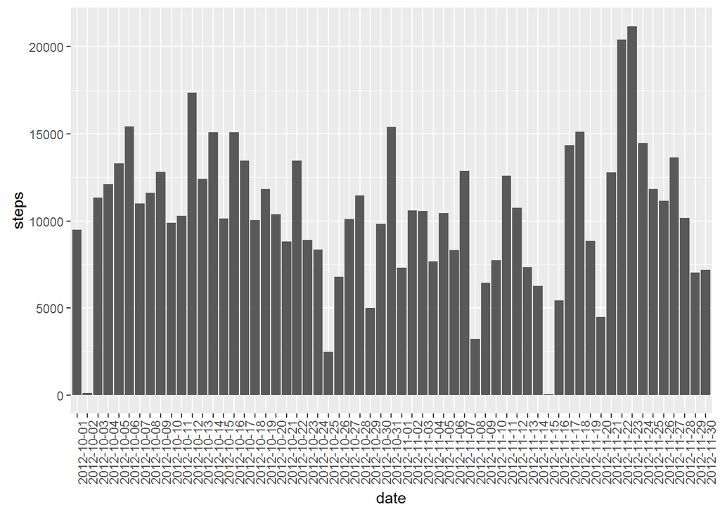

```r
 ggplot(dataimputed,aes(x=date, y=steps)) + geom_bar(stat = "identity") + theme(axis.text.x = element_text(angle = 90, hjust = 1))
```

```r
meansteps<-mean(dataimputed$steps)
meansteps
```

```
## [1] 36.11071
```

```r
mediansteps<-median(dataimputed$steps)
mediansteps
```

```
## [1] 0
```

## Are there differences in activity patterns between weekdays and weekends?

1. Create a new factor variable in the dataset with two levels - “weekday” and “weekend” indicating whether a given date is a weekday or weekend day.

```r
dataimputed$datetype <-  ifelse(as.POSIXlt(dataimputed$date)$wday %in% c(0,6), 'weekend', 'weekday')
head(dataimputed)
```

```
##   steps       date interval datetype
## 1     0 2012-10-01        0  weekday
## 2     0 2012-10-01        5  weekday
## 3     0 2012-10-01       10  weekday
## 4     0 2012-10-01       15  weekday
## 5     0 2012-10-01       20  weekday
## 6     0 2012-10-01       25  weekday
```

2. Make a panel plot containing a time series plot

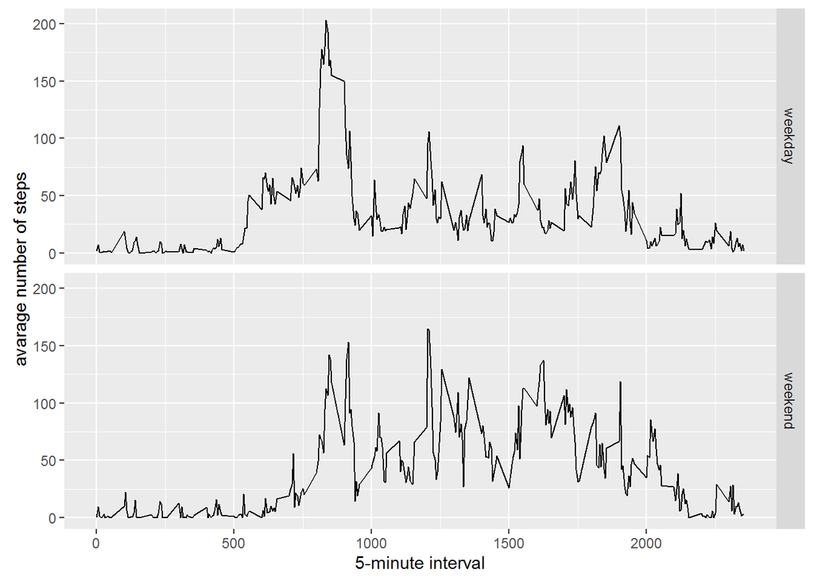

```r
averagedActivityDataImputed <- aggregate(steps ~ interval + datetype, data=dataimputed, mean)
ggplot(averagedActivityDataImputed, aes(interval, steps)) +    geom_line() + facet_grid(datetype ~ .) + xlab("5-minute interval") + ylab("avarage number of steps")
```